# Inverts User Manual

An R package for conditioning operating models and conducting MSE for informing management of hand harvested invertebrate fisheries in B.C.

Tom Carruthers (tom@bluematterscience.com)

2025-12-19

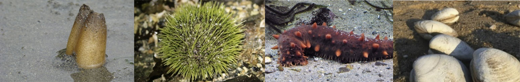

[figure not shown]

# 1 Foreword

Fisheries for hand-harvested invertebrates (HHI) present opportunities and challenges for science and management that are often not pertinent to fisheries for pelagic finfish.

Populations at the scale of the B.C. coastline are likely to have regional sub-population dynamics at varying spatial scales with uncertain larval dispersal and exchange of biomass. Data on HHI may come from a mix of commerical, recreational and organized scientific surveys that are often not available for earlier time periods of substantial exploitation.

While aspects of population dynamics and structure may be highly uncertain, the prescriptive nature of management measures (e.g. minimum size limits, rotational spatial closures, gear restrictions) for HHI could be highly robust and support the sustainable exploitation of productive stocks.

This research and decision support tools use operating models and MSE (Management Strategy Evaluation) simulation testing to characterize scientific uncertainty to inform robust management decision making.

# 2 Objective of this document

This document is intended to describe the decision support tools and guide prospective users through various aspects of MSE analyses providing examples on how to:

- specify and condition operating models
- calculate reference points
- modify operating models
- define and calculate management performance metrics
- design and test management procedures
- produce their own plots and diagnostics

# 3 Version Notes

The package is subject to ongoing testing and development. If you find a bug or a problem please send a report to tom@bluematterscience.com so that it can be fixed!

# 4 Introduction

## 4.1 Hand Harvested Invertebrates

As part of the approach to meeting the Fish Stocks provisions (FSP) in the revised Fisheries Act, DFO’s Marine Invertebrate Section (MIS) has been adapting the Management Procedure (MP) Framework (Anderson et al. 2021), a decision support tool, to support investigation of management decisions related to conservation objectives for Pacific marine invertebrates. This project will result in a decision support tool for exploring impacts of spatial closures (Marine Spatial Planning) and other management actions, in order to better understand trade-offs for decision makers under future marine ecosystem and human use (primarily fishing) scenarios.

These libraries adapt existing tools of the MP Framework to: define reference case and robustness operating models (OMs); define quantitative performance metrics; test alternative management procedures, calculate appropriate reference points, with management options relevant for marine invertebrates; and determining additional management objectives beyond the FSP for the four case studies (Geoduck, intertidal clams, Green Sea Urchin, and Giant Red Sea Cucumber).

## 4.2 Background information

Project information, links and results are available from a [project webpage](https://mis-assess.github.io/csrf_hh_io/3369975a9851e6fd41a0ae6865456662040af596/index.html)

## 4.3 Software

The [openMSE R package](https://openmse.com) was used to organize fishery data, define operating models, condition operating models to data, calculate reference points and specify and test existing and alternative management options.

The [Rapid Conditioning Model](https://openmse.com/tutorial-rcm/) was used to fit operating models to observed data.

[Reference Point Calculator (Huynh et al. )](https://shiny.bluematterscience.com/app/rpc) was used to explore fishery reference points

Objects and code are organized into a generic package ‘Inverts’ and a series of species-specific packages (e.g., Inverts.GD, Inverts.MC, Inverts.GSU, Inverts.SC for geoduck, manila clam, green sea urchin and sea cucumber, respectively).

Organizing the packages this way means that unnecessary objects do not need to be loaded when working on a particular species. Additionally the framework can be scaled to new species and allows for individual improvements to particular species without impacting the other packages.

| Inverts | The umbrella R package containing generic code and example objects for each case study stock |
| --- | --- |
| Inverts.GD | Data, operating models and tools specific to Geoduck |
| Inverts.MC | Data, operating models and tools specific to Manila Clam |
| Inverts.GSU | Data, operating models and tools specific to Green Sea Urchin |
| Inverts.SC | Data, operating models and tools specific to Giant Red Sea Cucumber |

Data, operating models, analyses and R packages are stored on the following GitHub repositories

| mis-assess/csrf_hh_data | Raw data, background analyses, supporting documentation for project | Private |
| --- | --- | --- |
| mis-assess/csrf_hh_io | Project splash page | Public |
| blue-matter/Inverts | Inverts R package | Public |
| blue-matter/Inverts.GD | Inverts.GD R package | Public |
| blue-matter/Inverts.MC | Inverts.MC R package | Public |
| blue-matter/Inverts.GSU | Inverts.GSU R package | Public |
| blue-matter/Inverts.SC | Inverts.SC R package | Public |

# 5 Installation

1. Install [R for Windows](https://cran.r-project.org/bin/windows/)
2. Install [RStudio](https://www.rstudio.com/products/rstudio/download/)
3. Install openMSE and devtools packages

Open RStudio and enter the following commands into the console:

```r
install.packages('openMSE')
install.packages('devtools')
```

4. Install github packages including the Inverts and RPC R packages by opening RStudio and entering the following commands at the R console :

```r
devtools::install_github("blue-matter/RPC")
devtools::install_github("blue-matter/Inverts")
```

5. Install any species specific packages

```r
devtools::install_github("blue-matter/Inverts.GD") # Geoduck
devtools::install_github("blue-matter/Inverts.MC") # Manila clam
```

6. Check that the installation is successful by finding this help file (the Inverts vignette):

```r
library(Inverts)
vignette('Inverts')
```

If you have any difficulties please send an inquiry including some reproducible code to: tom@bluematterscience.com

# 6 Quick start: run an MSE with pre-specified objects

Load libraries:

```r
library(Inverts)
library(Inverts.MC)
```

Locate a stock to work with:

```r
objs('In')         # objects of class input ('In')
```

```
#> Searching for objects of class In in package: Inverts
#> Searching for objects of class In in package: Inverts.GD
#> Searching for objects of class In in package: Inverts.MC
#>  [1] "In.GD.1"   "In.GD.106" "In.GD.12"  "In.GD.13"  "In.GD.14"  "In.GD.15"
#>  [7] "In.GD.16"  "In.GD.17"  "In.GD.18"  "In.GD.19"  "In.GD.2"   "In.GD.23"
#> [13] "In.GD.24"  "In.GD.25"  "In.GD.26"  "In.GD.27"  "In.GD.3"   "In.GD.4"
#> [19] "In.GD.5"   "In.GD.6"   "In.GD.7"   "In.GD.8"   "In.MC.C"   "In.MC.D"
#> [25] "In.MC.E"   "In.MC.F"
```

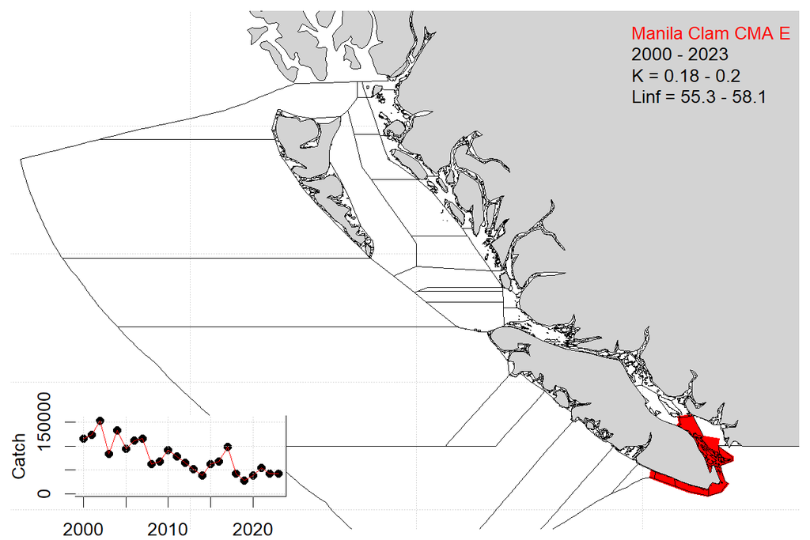

```r
about(In.MC.E)     # where is this?
```

Condition an operating model for Manila Clam in CMA E and plot the fit:

```r
myfit = cond.MC(In.MC.E)
plot(myfit)
```

Build the historical simulation:

```r
Hist = runMSE(myfit@OM, Hist=T)
```

Calculate historical levels relative to reference points:

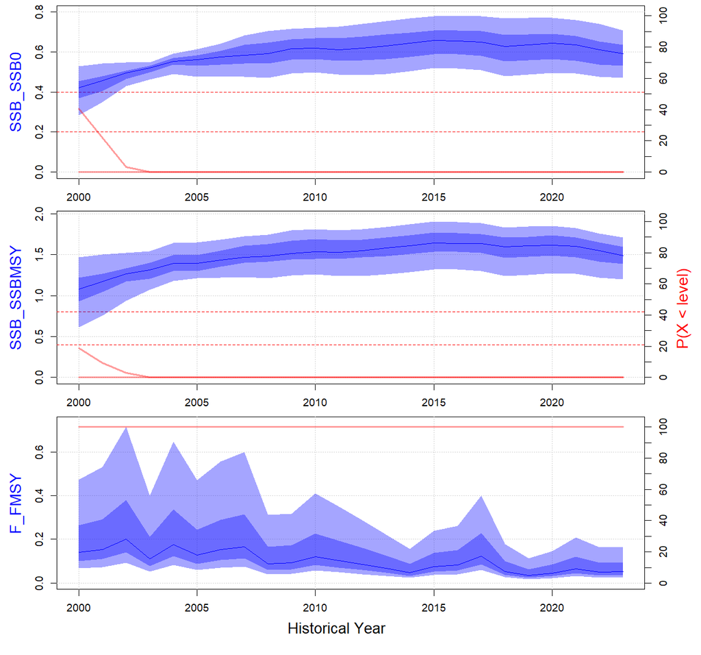

```r
RPs = Ref.Points(Hist)
```

Quantify current stock status:

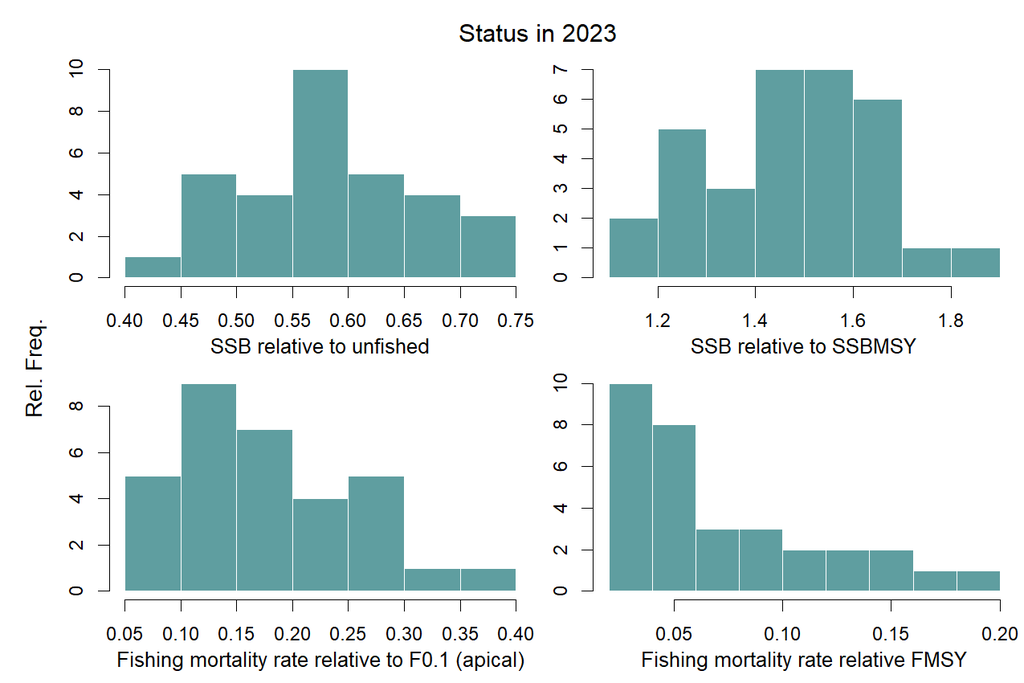

```
#> $SSB_SSB0
#>  [1] 0.4610 0.4896 0.6213 0.5724 0.7093 0.5927 0.5080 0.5980 0.5586 0.5436
#> [11] 0.6989 0.5919 0.5011 0.4337 0.7043 0.6705 0.5918 0.6463 0.5365 0.6874
#> [21] 0.5946 0.5952 0.6089 0.4805 0.5515 0.5904 0.4890 0.4778 0.6299 0.7176
#> [31] 0.6209 0.6538
#>
#> $SSB_SSBMSY
#>  [1] 1.2762 1.2438 1.5581 1.5906 1.5521 1.6405 1.2987 1.7274 1.4393 1.4272
#> [11] 1.4731 1.8246 1.3928 1.1431 1.5741 1.6345 1.5903 1.3602 1.4067 1.4718
#> [21] 1.5815 1.4919 1.6031 1.1908 1.3907 1.4854 1.2399 1.2056 1.6559 1.6081
#> [31] 1.5366 1.6894
#>
#> $F_F01
#>  [1] 0.3575 0.2505 0.1381 0.2268 0.0649 0.1634 0.2194 0.1587 0.1796 0.1931
#> [11] 0.0831 0.1666 0.2762 0.3331 0.0771 0.1046 0.1457 0.1321 0.2389 0.0800
#> [21] 0.2065 0.1275 0.1467 0.2522 0.1963 0.1395 0.2543 0.2591 0.1276 0.0715
#> [31] 0.1568 0.1234
#>
#> $F_FMSY
#>  [1] 0.1596 0.1241 0.0404 0.0751 0.0265 0.0421 0.1011 0.0425 0.0770 0.0898
#> [11] 0.0360 0.0507 0.0863 0.1719 0.0251 0.0281 0.0523 0.0428 0.1102 0.0308
#> [21] 0.0487 0.0523 0.0353 0.1437 0.0932 0.0747 0.1344 0.1815 0.0318 0.0231
#> [31] 0.0400 0.0306
```

```r
Status(Hist)
```

Simulation test status quo fishing pressure / catches and reference fishing:

```r
myMSE = Project(Hist, c('MP.MC',               # status quo manila clam management
                        "FMSYref50",           # perfect implementation of 50% FMSY fishing
                        "CurC"))               # constant current catch levels
```

Plot projected SSB and exploitation relative to MSY levels:

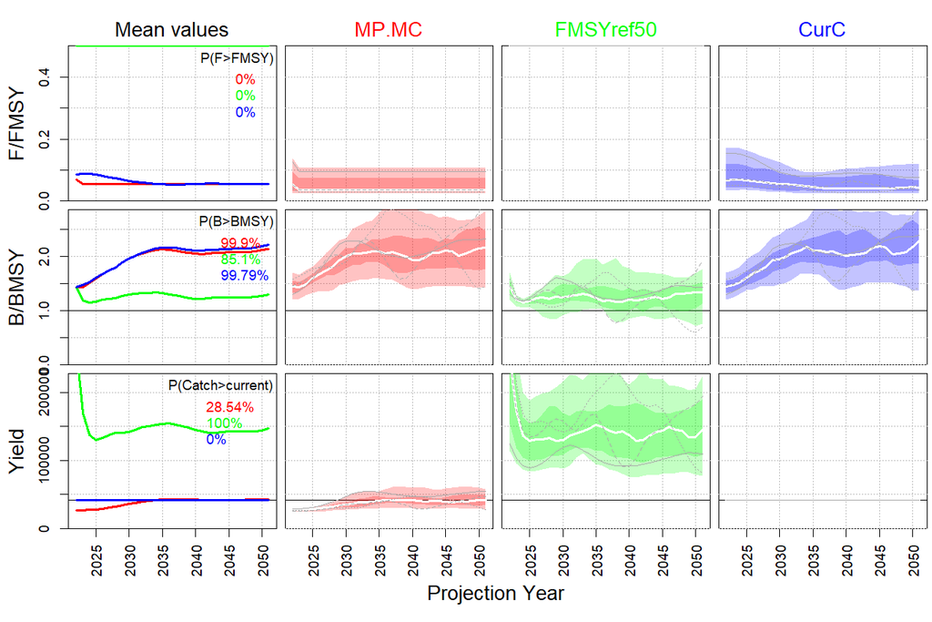

```r
Splot(myMSE)
```

Status at the end of the projection:

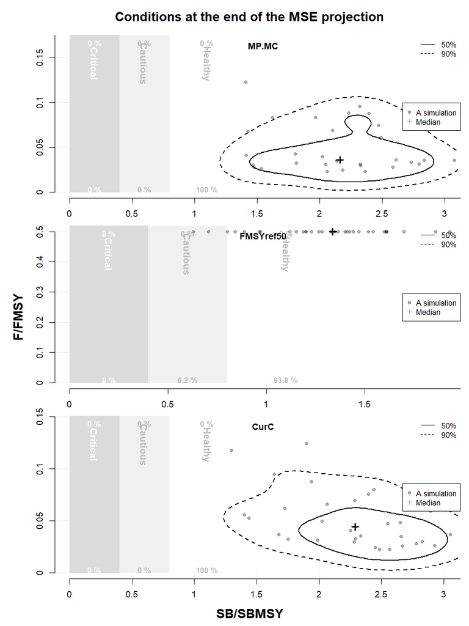

```r
DFO_proj(myMSE)
```

Tabulation of DFO-related probabilities:

```r
DFO_tab(myMSE)[1:3,] # ?DFO_tab to find out more
```

```
#>          MP P_Cr_S P_Ct_S P_H_S POF_S STY P_Cr_L P_Ct_L P_H_L POF_L LTY AAVY
#> 2 FMSYref50      0      1    99     0 103      0      5    95     0  94    7
#> 3      CurC      0      0   100     0  31      0      0   100     0  31    0
#> 1     MP.MC      0      0   100     0  23      0      0   100     0  30    3
#>   P_Reb
#> 2    91
#> 3   100
#> 1   100
```

# 7 Specifying Operating Models

## 7.1 Objects and data

The Inverts package includes all of the generic functions for searching for objects, interrogating operating models, running MSEs and plotting results.

The package comes with reference operating models (class OM) already conditioned for each species (e.g. OM_GD_7 is the operating model for Geoduck in management area 7).

You can search the loaded Inverts packages for any object of a given class using the objs() function:

```r
library(Inverts)
objs('OM')  # lists all objects of class 'OM' in the loaded Inverts packages
```

```
#> Searching for objects of class OM in package: Inverts
#> Searching for objects of class OM in package: Inverts.GD
#> Searching for objects of class OM in package: Inverts.MC
#> [1] "OM.GD.7"   "OM.GSU.12" "OM.MC.E"   "OM.RSC.7F"
```

When you load a species-specific library, you get bespoke input files (class ‘In’) and functions specific to that species:

```r
library(Inverts.GD)   # load the geoduck library
objs('In')  # lists all objects of class 'In' in the loaded Inverts packages
```

```
#> Searching for objects of class In in package: Inverts
#> Searching for objects of class In in package: Inverts.GD
#> Searching for objects of class In in package: Inverts.MC
#>  [1] "In.GD.1"   "In.GD.106" "In.GD.12"  "In.GD.13"  "In.GD.14"  "In.GD.15"
#>  [7] "In.GD.16"  "In.GD.17"  "In.GD.18"  "In.GD.19"  "In.GD.2"   "In.GD.23"
#> [13] "In.GD.24"  "In.GD.25"  "In.GD.26"  "In.GD.27"  "In.GD.3"   "In.GD.4"
#> [19] "In.GD.5"   "In.GD.6"   "In.GD.7"   "In.GD.8"   "In.MC.C"   "In.MC.D"
#> [25] "In.MC.E"   "In.MC.F"
```

Input object are specific to a particular region. You can plot the areas and some details of the operating models using the about() function:

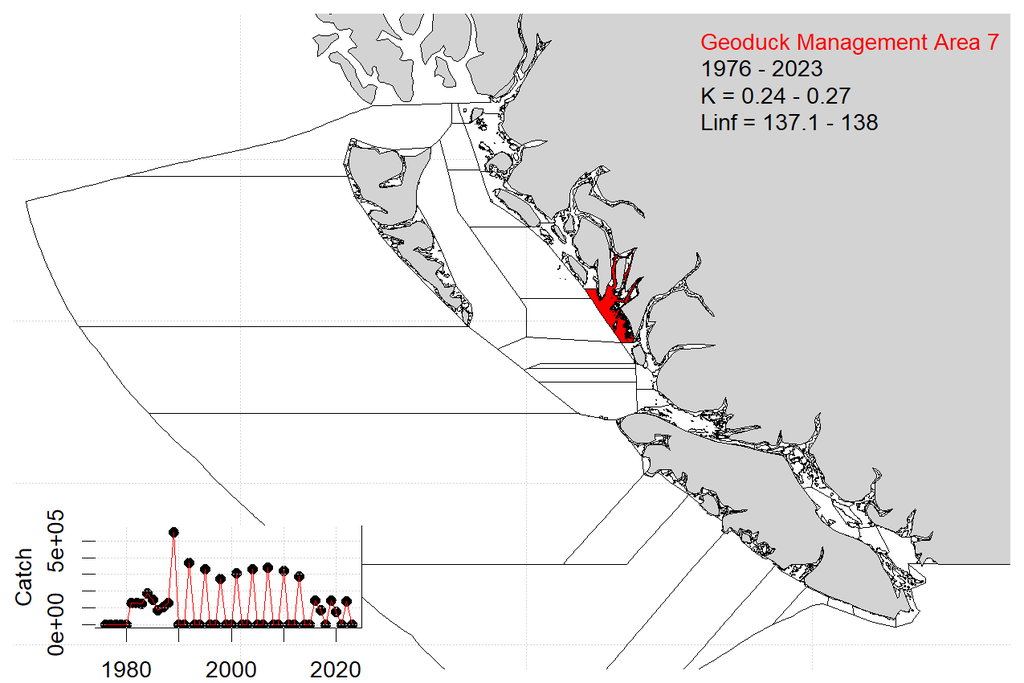

```r
about(In.GD.7)  # Plot some information about the input object
```

This also works for operating model objects which may have more information if they have been conditioned on data (such as unfished recruitment R0 (millions) and stock depletion (recent SSB relative to unfished):

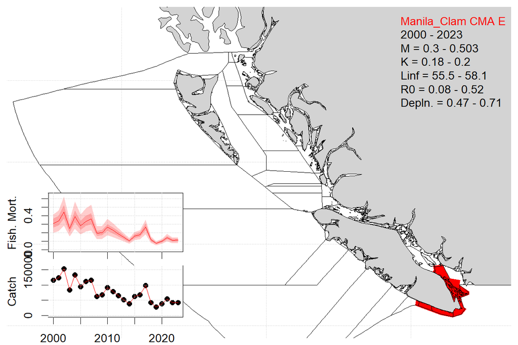

```r
about(OM.MC.E)  # Plot some information about an operating model
```

If you don’t want the figure and just want the data you can alter some arguments of the about function

```r
about(OM.GD.7, plot.fig = F, ret.dat = T)  # Extract only the data
```

```
#> $Name
#> [1] "Geoduck Management Area 7"
#>
#> $Years
#> [1] 1976 2023
#>
#> $M
#>    5%   95%
#> 0.042 0.070
#>
#> $K
#>   5%  95%
#> 0.24 0.26
#>
#> $Linf
#>    5%   95%
#> 137.3 138.0
#>
#> $R0
#>   5%  95%
#> 2.69 4.59
#>
#> $Depln.
#>   5%  95%
#> 0.75 0.85
```

Remember all of the functions are documented and can be accessed with the ? operator:

```r
?about
```

The input objects are the smallest and most concise basis for creating operating models and MSE analyses in a reproducible way. These objects contain the parameters and data required to condition operating models using the Rapid Conditioning Model (RCM) of OpenMSE.

```r
names(In.GD.7)             # slot 1 is the name, slot 2 is the OM parameters, slot 3 contains the data
class(In.GD.7$OM)          # this object is of class 'OM' for operating model, containing all parameters for the OM
class?OM                   # find out more about this class

class(In.GD.7$RCMdata)     # this object is of class 'RCMdata', containing all fishery data used for conditioning the OM
class?RCMdata              # find out more about this class

slotNames(In.GD.7$RCMdata) # list all the data types included in the object
In.GD.7$RCMdata@Chist      # the historical catches
```

## 7.2 Conditioning operating models

Using these input objects you can condition an operating model for this stock unit. The reason this is done at this level (we don’t provide pre-fitted OMs, other than the demonstration reference operating models in the Inverts package) is because you require control over the number of simulations to run. For example, in this script or a workshop we might wish to demonstrate functionality quickly using only a few simulations. In a setting where management advice is to be followed you might want 200+ simulations.

Each input object has up to 500 simulations already specified.

```r
?cond.MC()
myfit = cond.MC(In.MC.E, sims=24)
```

Once you have a fitted operating model the first thing you might wish to do is visualize the data, fit to data and model estimates:

```r
plot(myfit)
```

Alternatively, you could focus on the operating model characteristics including those parts of the operating model that simulate data and implement advice:

```r
plot(myfit@OM)
```

# 8 Calculating reference points

## 8.1 The Inverts Package

The Inverts package contains functions for the extraction and plotting of management reference points.

Firstly, you need to reconstruct the historical fishery in your R session using the runMSE() function with argument Hist=T. This means that the historical spool-up period of the operating model (before you were do to management projections) is calculated including a very wide range of reference points and quantities relating to reference points.

In later steps, projections will be undertaken to test management options (data quality, management procedures etc). By pre-calculating the historical stock and reference points, you don’t have to do this every time you do a projection (historical dynamics are fixed for each operating model) which makes simulation testing faster.

```r
Hist = runMSE(myfit@OM, Hist=T)
```

You can obtain a tabulated summary of reference points for a Hist object using the Ref.Points function:

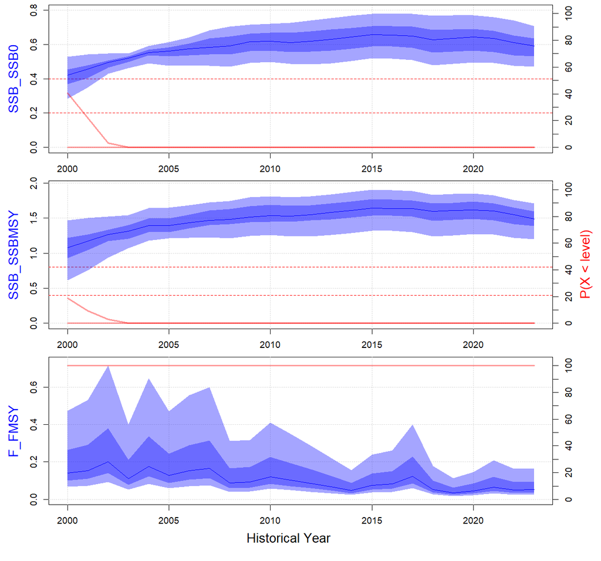

```r
RPs = Ref.Points(Hist)
```

```r
names(RPs)                 # names of listed reference points
```

```
#> [1] "SSB_SSB0"   "SSB_SSBMSY" "F_FMSY"
```

```r
head(RPs$SSB_SSB0)         # start of the biomass relative to unfished entry
```

```
#>        Mean    X5.   X25.   X50.   X75.   X95. P20    P40
#> 2000 0.4105 0.2829 0.3677 0.4202 0.4542 0.5285   0 0.4062
#> 2001 0.4475 0.3499 0.4052 0.4556 0.4795 0.5405   0 0.2188
#> 2002 0.4876 0.4283 0.4639 0.4946 0.5062 0.5474   0 0.0312
#> 2003 0.5123 0.4612 0.4966 0.5185 0.5300 0.5482   0 0.0000
#> 2004 0.5487 0.4890 0.5357 0.5528 0.5679 0.5913   0 0.0000
#> 2005 0.5531 0.4745 0.5319 0.5600 0.5829 0.6125   0 0.0000
```

You can also use the internal plotting function on any of these tables if you want a single plot:

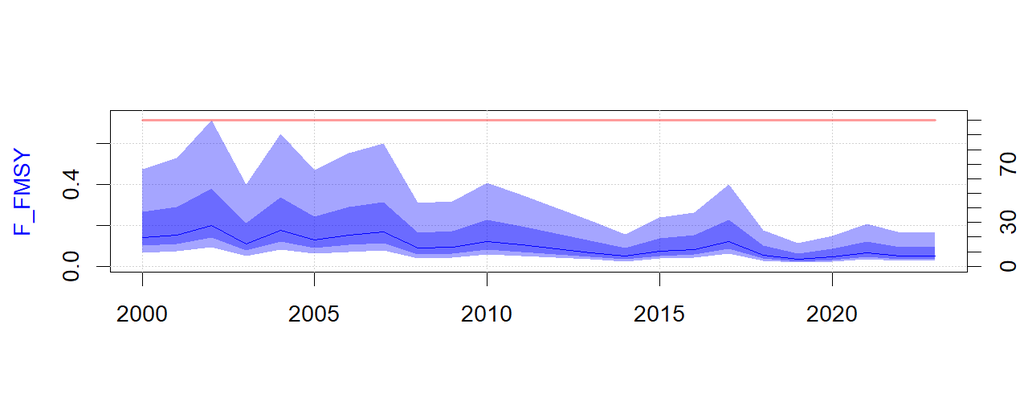

```r
RefPlot(RPs[[3]],names(RPs)[3])
```

For a summary of stock status in the most recent historical year two functions are provided:

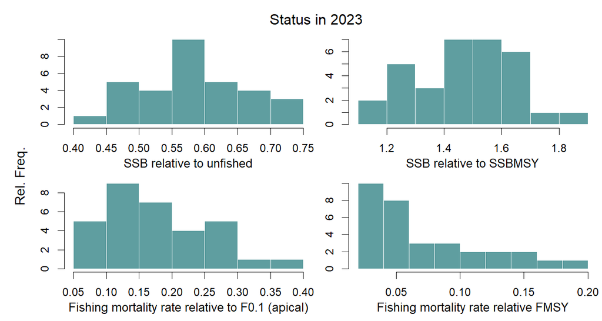

```
#> $SSB_SSB0
#>  [1] 0.4610 0.4896 0.6213 0.5724 0.7093 0.5927 0.5080 0.5980 0.5586 0.5436
#> [11] 0.6989 0.5919 0.5011 0.4337 0.7043 0.6705 0.5918 0.6463 0.5365 0.6874
#> [21] 0.5946 0.5952 0.6089 0.4805 0.5515 0.5904 0.4890 0.4778 0.6299 0.7176
#> [31] 0.6209 0.6538
#>
#> $SSB_SSBMSY
#>  [1] 1.2762 1.2438 1.5581 1.5906 1.5521 1.6405 1.2987 1.7274 1.4393 1.4272
#> [11] 1.4731 1.8246 1.3928 1.1431 1.5741 1.6345 1.5903 1.3602 1.4067 1.4718
#> [21] 1.5815 1.4919 1.6031 1.1908 1.3907 1.4854 1.2399 1.2056 1.6559 1.6081
#> [31] 1.5366 1.6894
#>
#> $F_F01
#>  [1] 0.3575 0.2505 0.1381 0.2268 0.0649 0.1634 0.2194 0.1587 0.1796 0.1931
#> [11] 0.0831 0.1666 0.2762 0.3331 0.0771 0.1046 0.1457 0.1321 0.2389 0.0800
#> [21] 0.2065 0.1275 0.1467 0.2522 0.1963 0.1395 0.2543 0.2591 0.1276 0.0715
#> [31] 0.1568 0.1234
#>
#> $F_FMSY
#>  [1] 0.1596 0.1241 0.0404 0.0751 0.0265 0.0421 0.1011 0.0425 0.0770 0.0898
#> [11] 0.0360 0.0507 0.0863 0.1719 0.0251 0.0281 0.0523 0.0428 0.1102 0.0308
#> [21] 0.0487 0.0523 0.0353 0.1437 0.0932 0.0747 0.1344 0.1815 0.0318 0.0231
#> [31] 0.0400 0.0306
```

```r
Status(Hist) # provides all the estimated values of SSB and F relative to reference points
```

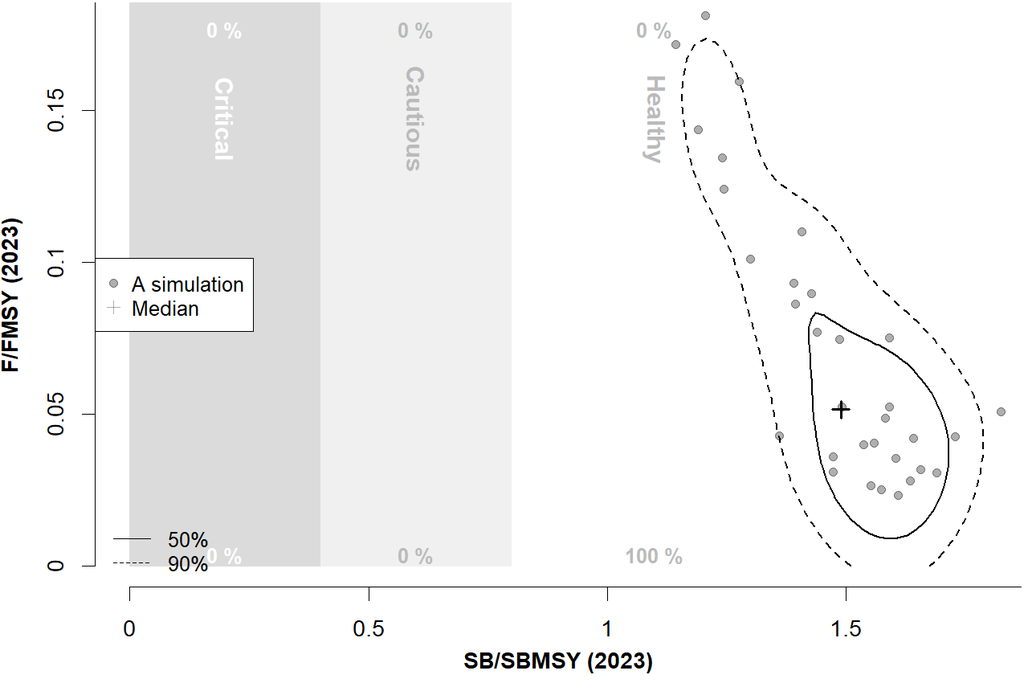

```r
DFO_status(Hist) # plot estimated values of SSB and F relative to reference points on standard DFO regions
```

If you would rather access all the raw data yourself, these are available in the Hist object in the following slots:

```r
names(Hist@TSdata)                  # Time series data like F (Find) and spawning biomass (SSB)
```

```
#>  [1] "Number"               "Biomass"              "VBiomass"
#>  [4] "SBiomass"             "Removals"             "Landings"
#>  [7] "Discards"             "Find"                 "RecDev"
#> [10] "SPR"                  "Unfished_Equilibrium"
```

```r
names(Hist@Ref$ReferencePoints)     # Equilibrium reference points (parameters for most recent historical year)
```

```
#>  [1] "N0"          "B0"          "SSB0"        "SSN0"        "VB0"
#>  [6] "MSY"         "FMSY"        "SSBMSY"      "BMSY"        "VBMSY"
#> [11] "UMSY"        "FMSY_M"      "SSBMSY_SSB0" "BMSY_B0"     "VBMSY_VB0"
#> [16] "RefY"        "MGT"         "Blow"
```

```r
names(Hist@Ref$ByYear)              # Equilibrium reference points calculated from parameters in each historical year
```

```
#>  [1] "N0"       "SN0"      "B0"       "SSB0"     "VB0"      "R0"
#>  [7] "h"        "MSY"      "FMSY"     "SSBMSY"   "BMSY"     "VBMSY"
#> [13] "F01_YPR"  "Fmax_YPR" "F_SPR"    "Fcrash"   "Fmed"     "SPRcrash"
```

```r
names(Hist@Ref$Dynamic_Unfished)    # Dynamic reference points (assuming no fishing for all years)
```

```
#> [1] "N0"   "B0"   "SN0"  "SSB0" "VB0"  "Rec"
```

It is possible to compare biological status across various operating models. Lets fit a second one and do the historical spool up:

```r
myfit2 = cond.MC(In.MC.C)
Hist2 = runMSE(myfit2@OM)
```

Now we can compare the current biomass estimate among the operating models:

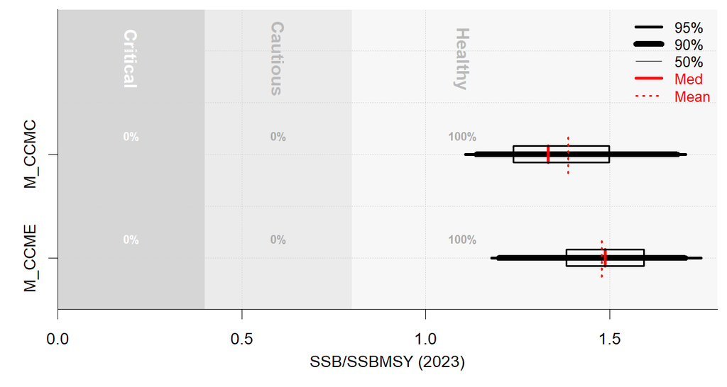

```
#>        P(Crit.) P(Caut.) P(Healthy)
#> M_CCME        0        0          1
#> M_CCMC        0        0          1
```

```r
DFO_status_comp(list(Hist,Hist2))
```

## 8.2 The Reference Point Calculator (RPC) Package

Reference Point Calculator (Huynh et al. 2022) is an R package and App designed for the exploration of reference points and the testing of management procedures / Harvest Control Rules (HCRs). The package was developed as part of a DFO grant and allows for the calculation of a very wide range of reference points.

Many of the RPC plotting functions use objects of class ‘Hist’ that are historical reconstructions of the type calculated above (using runMSE(OM, Hist=T)).

If you want a summary of the historical stock dynamics:

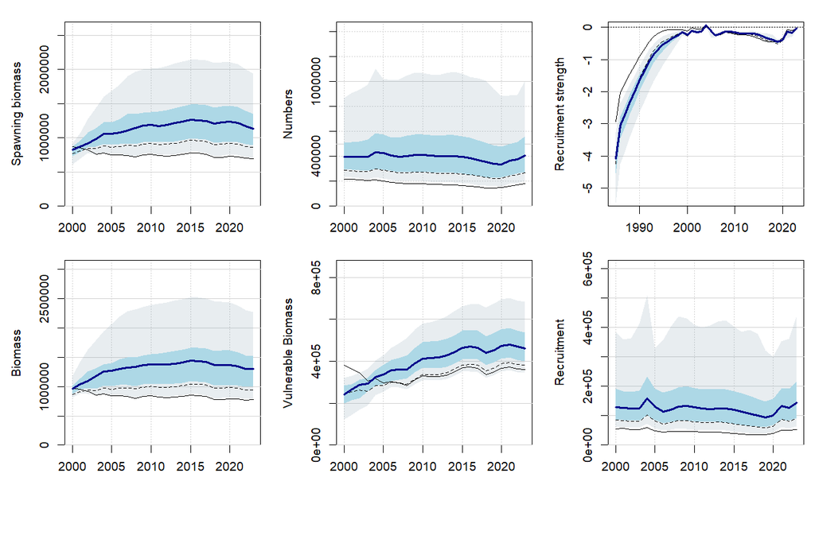

```r
hist_bio(Hist)
```

Also available are the yield curves (equilibrium catches at various population / exploitation levels):

```r
# hist_YieldCurve(Hist)
```

Here we plot the SSB history relative to MSY:

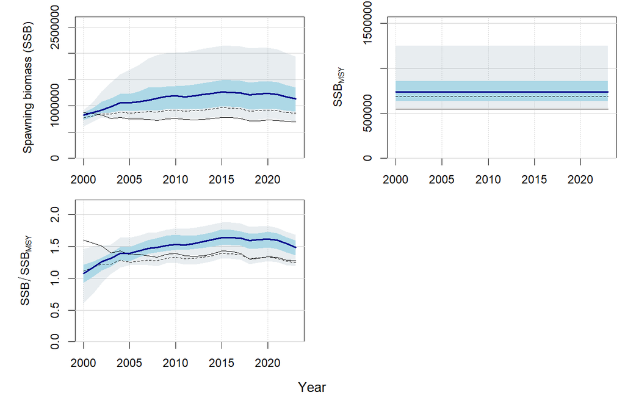

```r
LRP_SSBMSY(Hist)
```

Exploitation rate relative to FMSY:

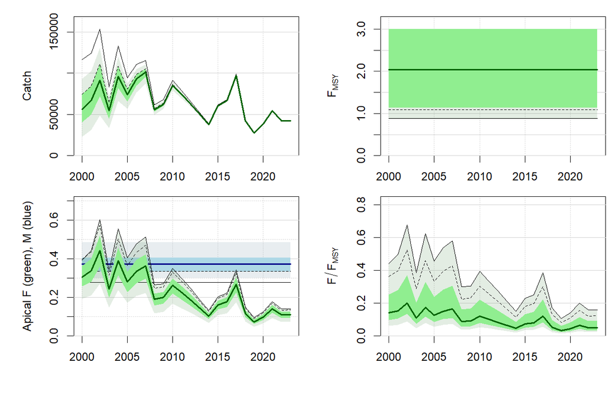

```r
LRP_FMSY(Hist)
```

Spawning Potential Ratio:

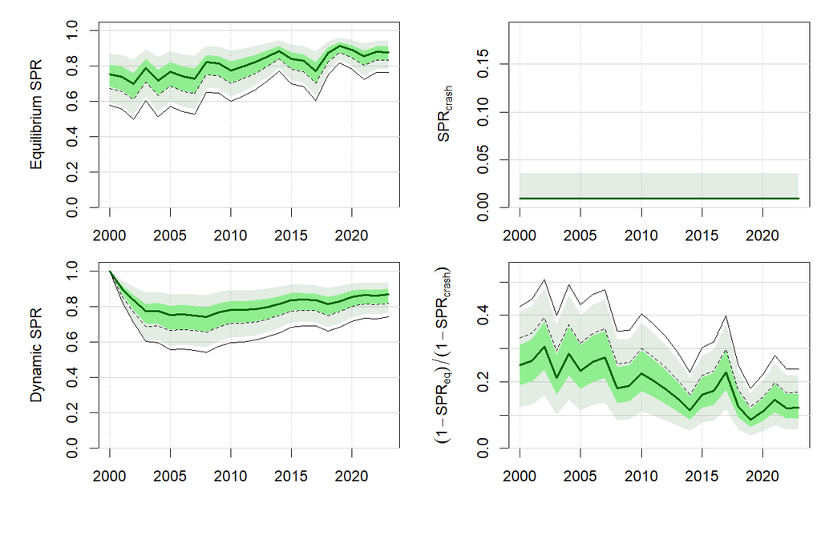

```r
LRP_SPR(Hist)
```

The historical recruitment:

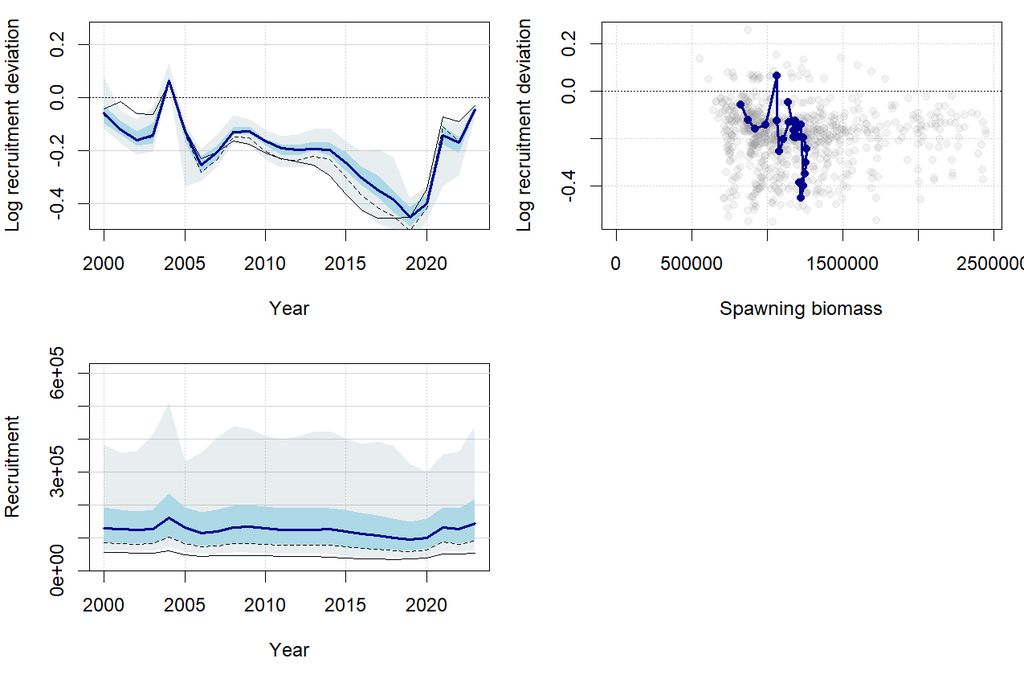

```r
LRP_R(Hist)
```

Spawning stock biomass (SSB) relative to the (mean) SSB corresponding to 50% max recruitment:

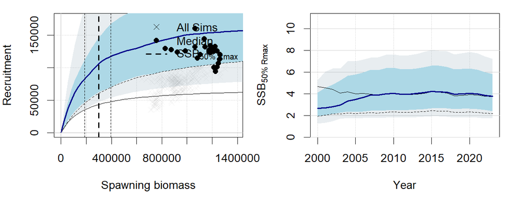

```r
LRP_50Rmax(Hist)
```

Historical surplus production:

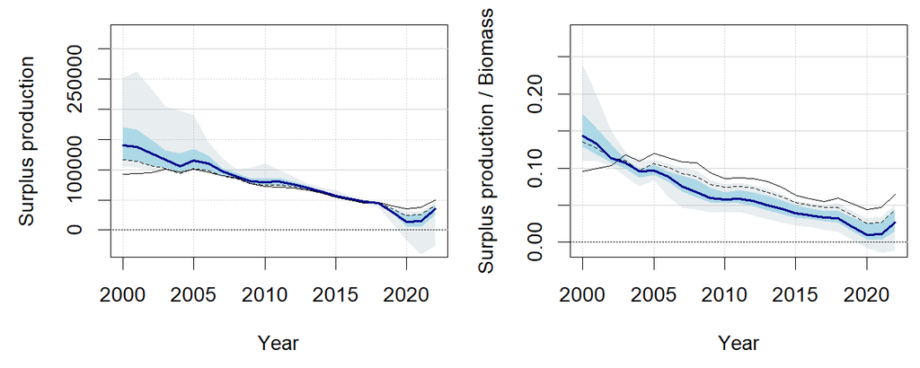

```r
LRP_SP(Hist)
```

## 8.3 The Reference Point Calculator online App

The operating model is fully compatible with the shiny app [Reference Point Calculator](https://shiny.bluematterscience.com/app/rpc) to provide a very comprehensive report on ALL fishery reference points ever described (including the various plots above) and also allows for the testing of management procedures.

To use the app you should save the operating model object to your computer, open the app link above and then upload your saved operating model object:

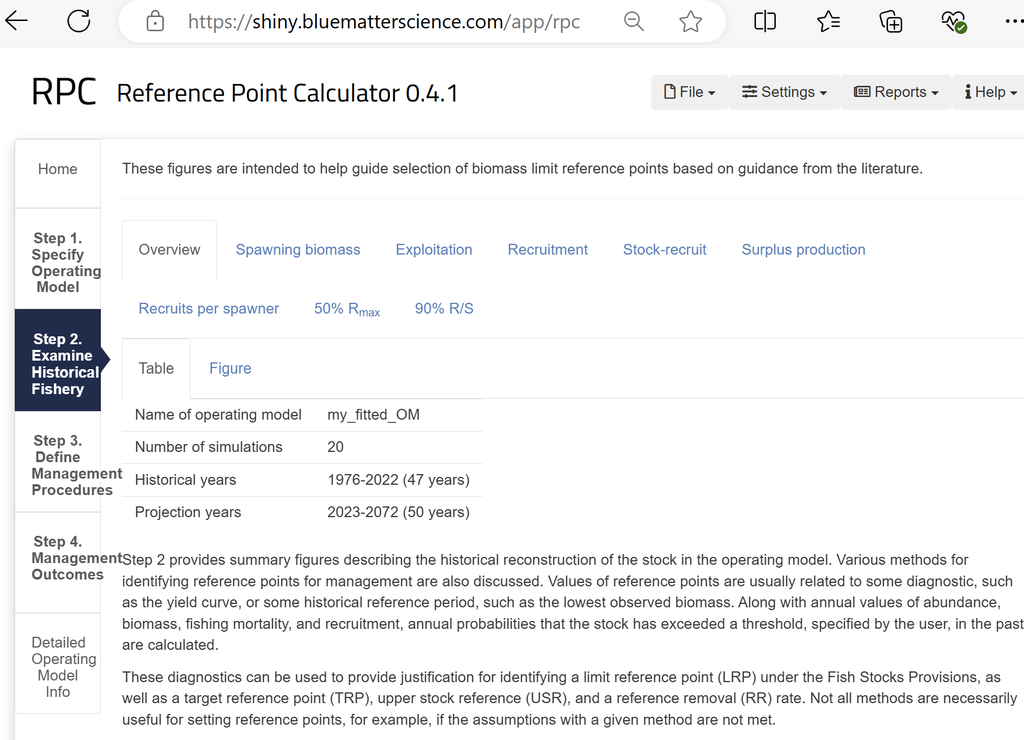

```r
saveRDS(myfit@OM, file="C:/temp/my_fitted_OM.rds") # this is the file you upload to the RPC app
```

# 9 Testing management procedures

## 9.1 Running simulations

Each species-specific R package has a dedicated ‘status quo’ management procedure. These can be easily found using the list objects function objs().

```r
objs('MP')  # invertebrates MPs
```

```
#> Searching for objects of class MP in package: Inverts
#> Searching for objects of class MP in package: Inverts.GD
#> Searching for objects of class MP in package: Inverts.MC
#> [1] "MP.GD" "MP.MC"
```

Many other MPs that are available for testing (from the openMSE libraries) can be found using the avail() function:

```r
avail('MP') # all MPs that have been loaded included those with openMSE pacakages
```

```
#> → Searching for objects of class "MP" in package "MSEtool"
#> → Searching for objects of class "MP" in package "SAMtool"
#> → Searching for objects of class "MP" in package "DLMtool"
#>   [1] "curEref"      "Emp"          "FMSYref"      "FMSYref50"    "FMSYref75"
#>   [6] "NFref"        "DDSS_4010"    "DDSS_75MSY"   "DDSS_MSY"     "SCA_4010"
#>  [11] "SCA_75MSY"    "SCA_MSY"      "SP_4010"      "SP_75MSY"     "SP_MSY"
#>  [16] "SSS_4010"     "SSS_75MSY"    "SSS_MSY"      "AvC"          "AvC_MLL"
#>  [21] "BK"           "BK_CC"        "BK_ML"        "CC1"          "CC2"
#>  [26] "CC3"          "CC4"          "CC5"          "CompSRA"      "CompSRA4010"
#>  [31] "CurC"         "curE"         "curE75"       "DAAC"         "DBSRA"
#>  [36] "DBSRA_40"     "DBSRA4010"    "DCAC"         "DCAC_40"      "DCAC_ML"
#>  [41] "DCAC4010"     "DCACs"        "DD"           "DD4010"       "DDe"
#>  [46] "DDe75"        "DDes"         "DepF"         "DTe40"        "DTe50"
#>  [51] "DynF"         "EtargetLopt"  "Fadapt"       "Fdem"         "Fdem_CC"
#>  [56] "Fdem_ML"      "Fratio"       "Fratio_CC"    "Fratio_ML"    "Fratio4010"
#>  [61] "GB_CC"        "GB_slope"     "GB_target"    "Gcontrol"     "HDAAC"
#>  [66] "ICI"          "ICI2"         "Iratio"       "Islope1"      "Islope2"
#>  [71] "Islope3"      "Islope4"      "IT10"         "IT5"          "Itarget1"
#>  [76] "Itarget1_MPA" "Itarget2"     "Itarget3"     "Itarget4"     "ItargetE1"
#>  [81] "ItargetE2"    "ItargetE3"    "ItargetE4"    "ITe10"        "ITe5"
#>  [86] "ITM"          "L95target"    "LBSPR"        "LBSPR_MLL"    "Lratio_BHI"
#>  [91] "Lratio_BHI2"  "Lratio_BHI3"  "LstepCC1"     "LstepCC2"     "LstepCC3"
#>  [96] "LstepCC4"     "LstepCE1"     "LstepCE2"     "Ltarget1"     "Ltarget2"
#> [101] "Ltarget3"     "Ltarget4"     "LtargetE1"    "LtargetE4"    "matlenlim"
#> [106] "matlenlim2"   "MCD"          "MCD4010"      "minlenLopt1"  "MRnoreal"
#> [111] "MRreal"       "Rcontrol"     "Rcontrol2"    "SBT1"         "SBT2"
#> [116] "slotlim"      "SPmod"        "SPslope"      "SPSRA"        "SPSRA_ML"
#> [121] "YPR"          "YPR_CC"       "YPR_ML"
```

Most of these are reference MPs (e.g., curE - fishing at current effort levels, FMSYref75 - fishing at 75% of perfectly known FMSY, NFref - no fishing) or ‘data limited’ MPs (e.g. DBSRA, DCAC, AvC, BK_ML). There are however a handful of data rich MPs that are full stock assessments so that it is possible to quantify the benefit of moving towards more analysis-heavy types of management (e.g., SP_MSY, DDSS_MSY, SCA_MSY etc.).

The invertebrate-specific MPs (e.g. MP.MC) are designed to closely follow existing management measures but have sufficient flexibility to accommodate a wide range of modifications so that management alternatives can be investigated (more on that below in the ‘Specifying management options’ section)

Running MSE projections uses the Project() function, where the historical simulation object (we made Hist earlier) is projected for at least one management scenario. Note that each simulation of this projection is identical in terms of recruitment deviation and observation error - the only difference is the MP, so simulation 1 for the first MP tested can be compared directly with simulation 1 for the other MPs. By sharing the same projected conditions, the relative differences among MPs are revealed more efficiently.

Here we do a projection of our status quo management MP for manila clam and and reference MP that fishes at half of perfectly know FMSY levels:

```r
myMSE = Project(Hist, c('MP.MC',               # status quo manila clam management
                        "FMSYref50",           # perfect implementation of 50% FMSY fishing
                        "CurC"))               # constant current catch levels
```

The object that was created (myMSE) is of class ‘MSE’ and contains a wide range of information about the operating model, reference points and the projected simulations:

```r
class?MSE
```

## 9.2 Performance metrics

Since the MSE object contains a comprehensive record of everything that was simulated in the projection, we can produce a large number of possible performance metrics. There are functions that provide outputs specific to particular management authorities. For example, there are DFO-specific plots that reference the probabilty of being in the critical, cautious and healthy zones over the short and long time periods:

```r
DFO_tab(myMSE)[1:3,]
```

```
#>          MP P_Cr_S P_Ct_S P_H_S POF_S STY P_Cr_L P_Ct_L P_H_L POF_L LTY AAVY
#> 2 FMSYref50      0      1    99     0 103      0      5    95     0  94    7
#> 3      CurC      0      0   100     0  31      0      0   100     0  31    0
#> 1     MP.MC      0      0   100     0  23      0      0   100     0  30    3
#>   P_Reb
#> 2    91
#> 3   100
#> 1   100
```

```r
?DFO_tab  # to find out more
```

```
#> starting httpd help server ... done
```

Other outputs include NOAA_plot that shows the probability of not overfishing, probability of being above 50% BMSY (P50), long term yield and the probability catch changes are less than 15% among management updates:

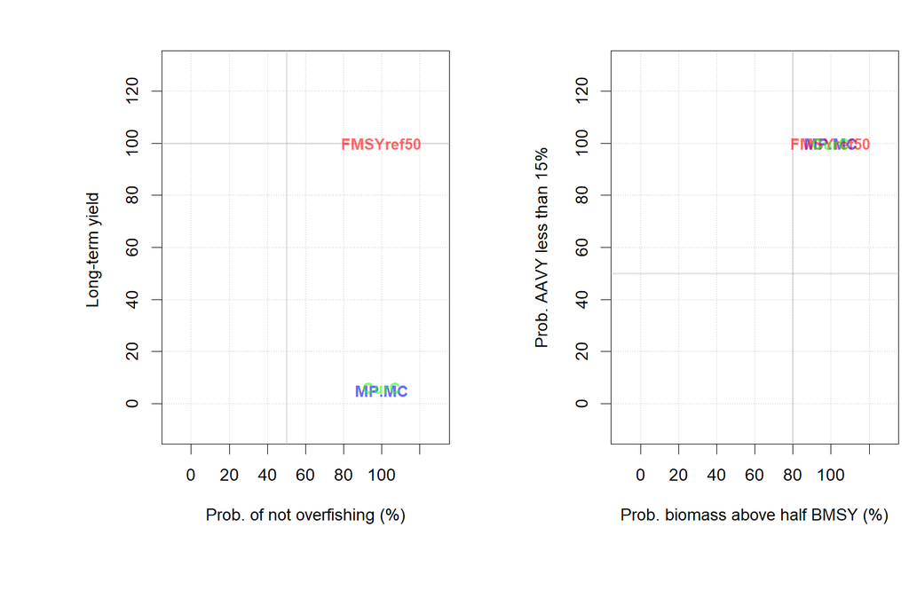

```
#>           PNOF B50   LTY  VY
#> MP.MC      100 100   5.0 100
#> FMSYref50  100 100 100.0 100
#> CurC       100 100   6.2 100
```

```r
NOAA_plot(myMSE)
```

## 9.3 Plotting results

You can visualize some of the MSE outcomes using built-in openMSE plotting functions (basic but fast):

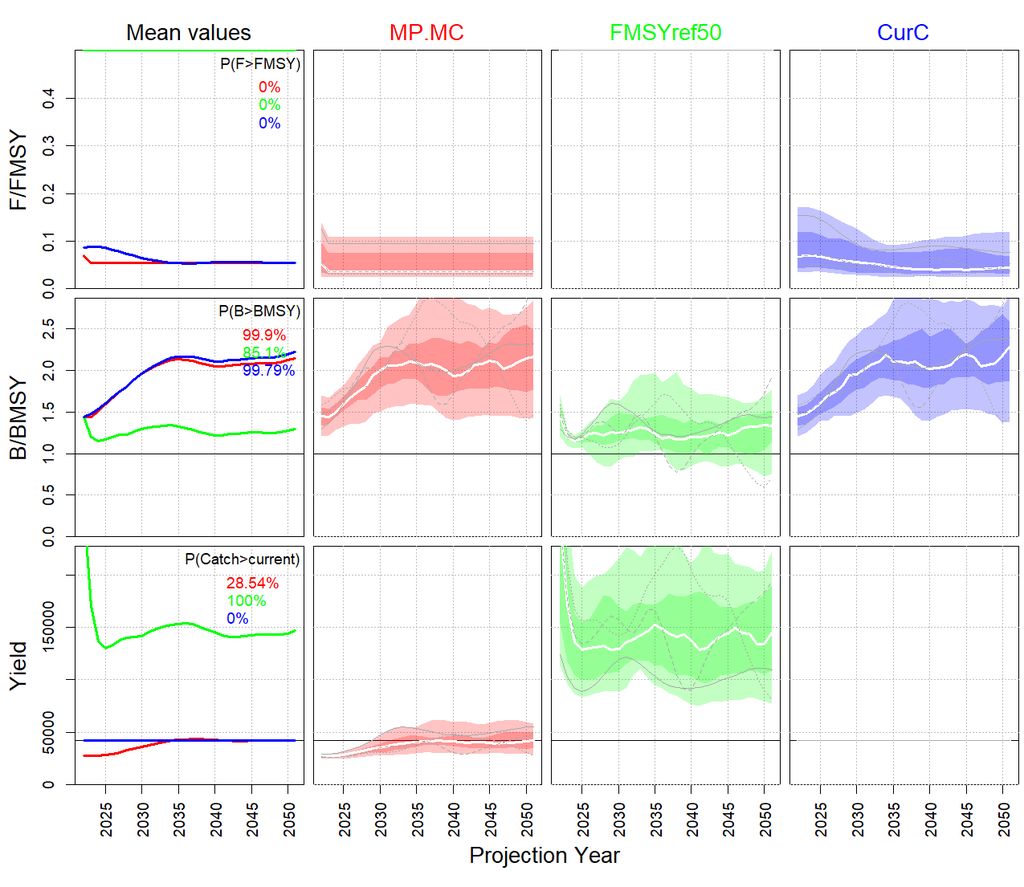

```r
Splot(myMSE)
```

There are also a set of DFO figures and diagnostics:

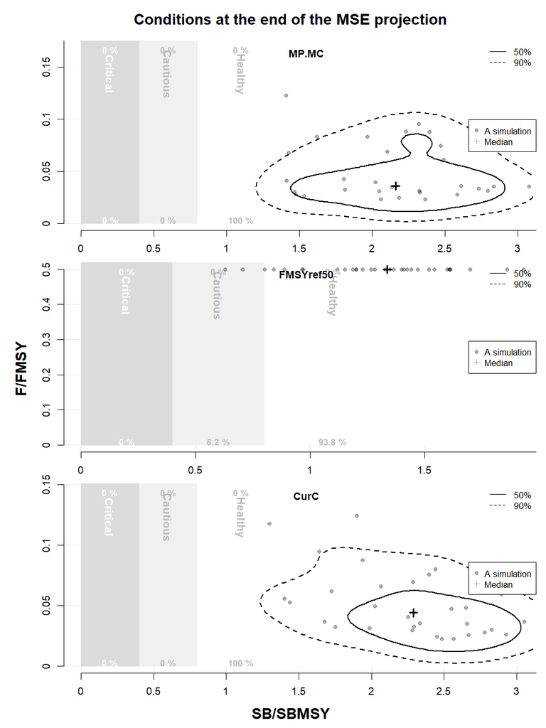

```r
DFO_proj(myMSE)
```

There are also a set of tradeoff plots that show median yield and biomass outcomes:

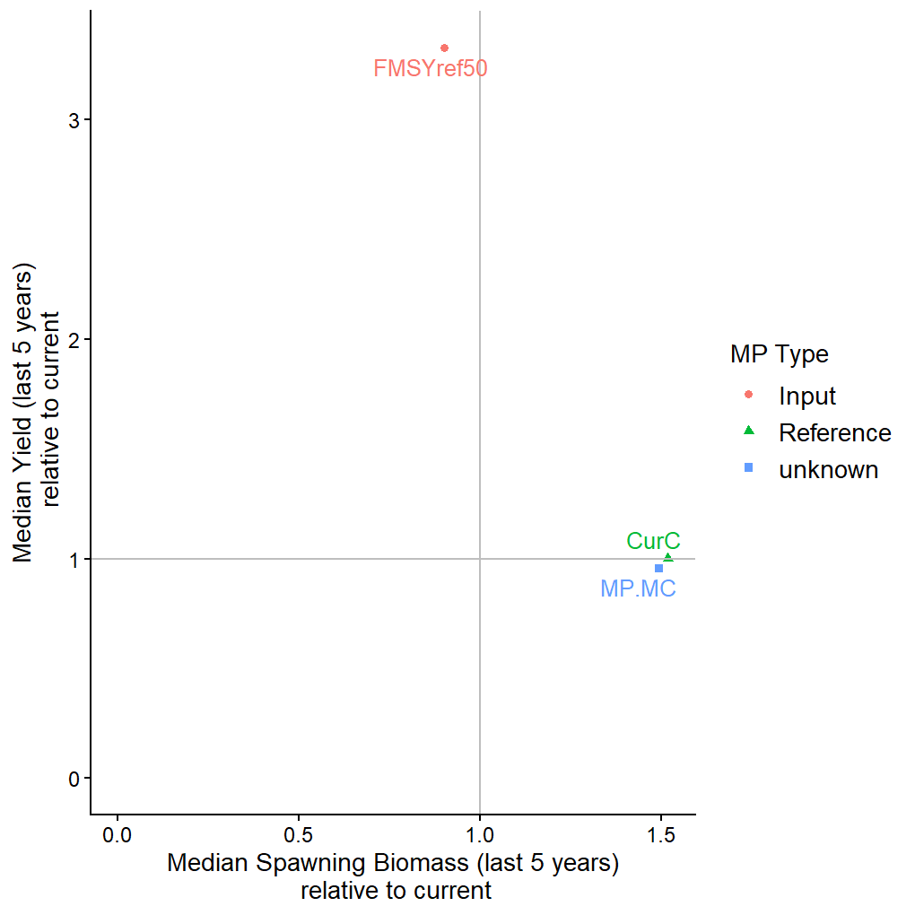

```r
Cplot(myMSE)
```

You do have access to all the data in the MSE object so can plot your own custom plots easily enough:

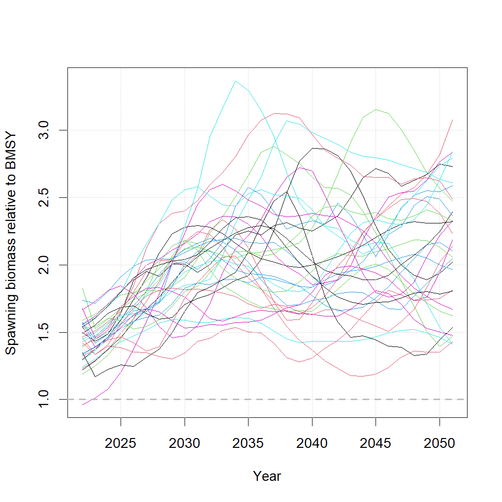

```r
Year = myMSE@OM$CurrentYr[1] + 1:myMSE@proyears
matplot(Year,t(myMSE@SB_SBMSY[,1,]),type="l",lty=1, ylab="Spawning biomass relative to BMSY"); grid()
abline(h=1,col="grey",lwd=2,lty=2)
```

## 9.4 Specifying management options

For example, the MP.MC function (default management procedure for manila clam) has the following arguments:

```r
args(MP.MC)
```

```
#> function (x, Data, reps = 1, Min.size = 35, Max.size = NaN, CEff.Mult = 1,
#>     C_I.targ = 1, I.targ = 0.5, IS.targ = 0, IS.yrs = 6, IS.fac = 1,
#>     TAC.calc = NaN, maxTAC = 5, minTAC = 0.1, TACdec = 0.2, TACinc = 0.1,
#>     I.enp = 0.25, I_freq = c(0, 1, 0), calib_yrs = 2, HCR_CP_B = c(0,
#>         0), HCR_CP_TAC = c(0, 1), curI_2_target = 2, DR = 0,
#>     Fdisc = 0.5)
#> NULL
```

You can find out what each of these arguments do via the in-line help:

```r
?MC.MP
```

The next section describes how these generic MPs can be modified to test a wide range of alternative management options.

# 10 Designing new management procedures

## 10.1 Status quo and reference management procedures

Before testing alternative management options it is beneficial to understand the range of outcomes that might be possible. Do do this it is advisable to run projections with reference MPs. Here we will evaluate ‘no fishing’, ‘FMSY fishing’, and status quo fishing.

```r
refMSE = Project(Hist, c('MP.MC',               # status quo manila clam management
                        "FMSYref",             # perfect implementation of FMSY fishing
                        "NFref"))              # no fishing
```

Projection plots let us understand how the FMSY and no fishing scenarios bracket our existing status quo management.

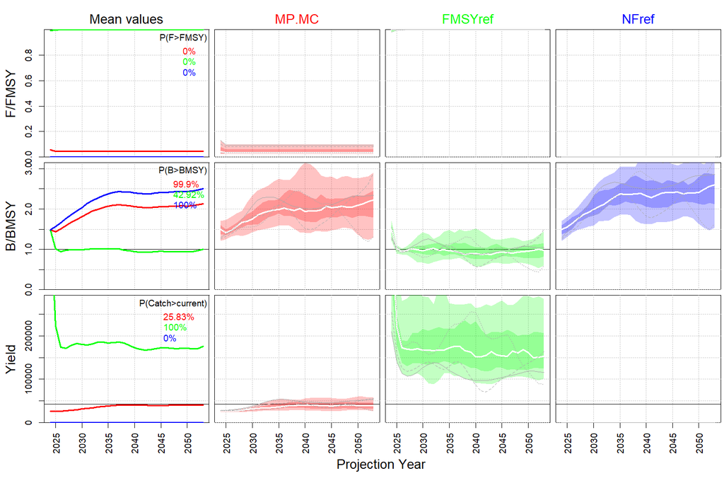

```r
Splot(refMSE)
```

## 10.2 Implementing size limits

By default, the manila clam MP imposes a minimum size limit of 35mm and keeps effort at current levels. If you wanted to test an alternative minimum size limit you would alter that particular argument:

```r
SL25 = MP.MC                   # copy the status quo management procedure
formals(SL25)$Min.size = 25    # set the size limit to 25mm
class(SL25) = 'MP'             # assign your new function the class 'MP'
```

Lets test it out:

```r
SL_MSE = Project(Hist, c("MP.MC","SL25"))
```

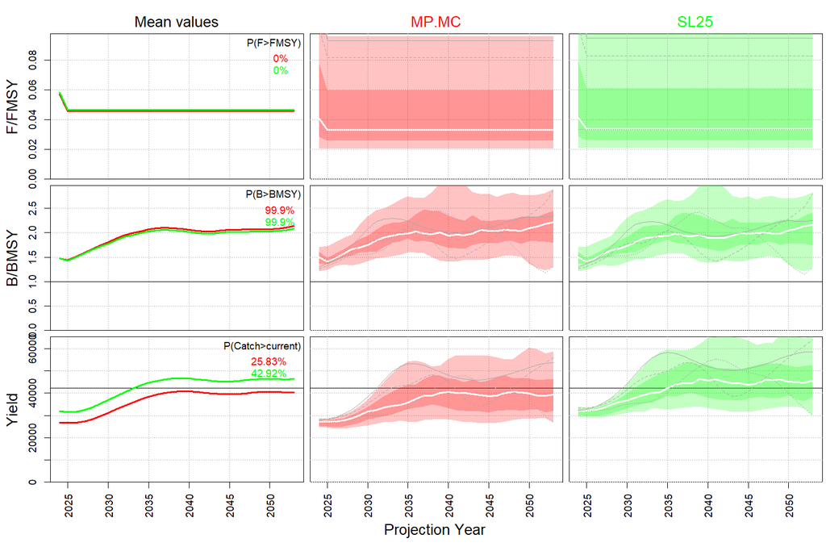

```r
Splot(SL_MSE)
```

Because both MPs are fishing much below FMSY the only impact of the size limit change is on the yield. Lets try this again with 25 adn 35mm size limits but with 20x the amount of fishing pressure as today:

```r
SL25_E20 = SL25                   # copy the basic operating model
formals(SL25_E20)$CEff.Mult = 20    # set the size limit to 25mm
class(SL25_E20) = 'MP'             # assign your new function the class 'MP'
SL35_E20 = MP.MC
formals(SL35_E20)$CEff.Mult = 20
SL_MSE_E20 = Project(Hist, c("SL25_E20","SL35_E20"))
```

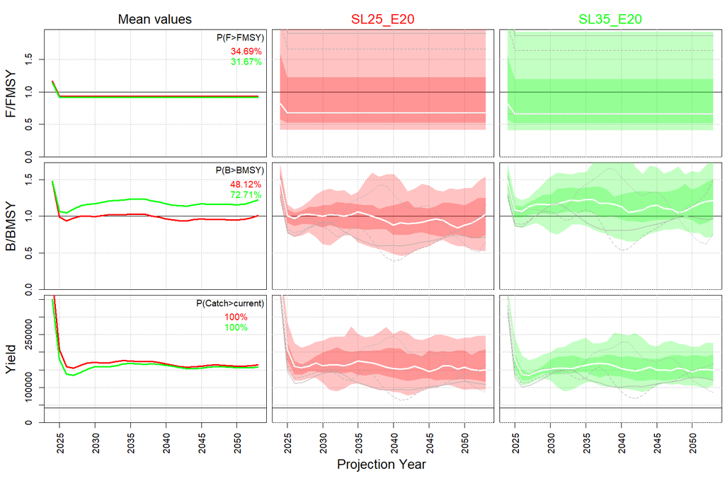

```r
Splot(SL_MSE_E20)
```

Now we can see closer to FMSY fishing pressure, more comparable yield outcomes but somwehatever higher biomass outcomes for the higher size limit.